# ISLR Chapter 4 - applied

## Exercise 10

**This question should be answered using the `Weekly` data set, which is part of the `ISLR` package. It contains 1,089 weekly returns for 21 years, from the beginning of 1990 to the end of 2010.**

**Produce some numerical and graphical summaries of the `Weekly` data. Do there appear to be any patterns?**

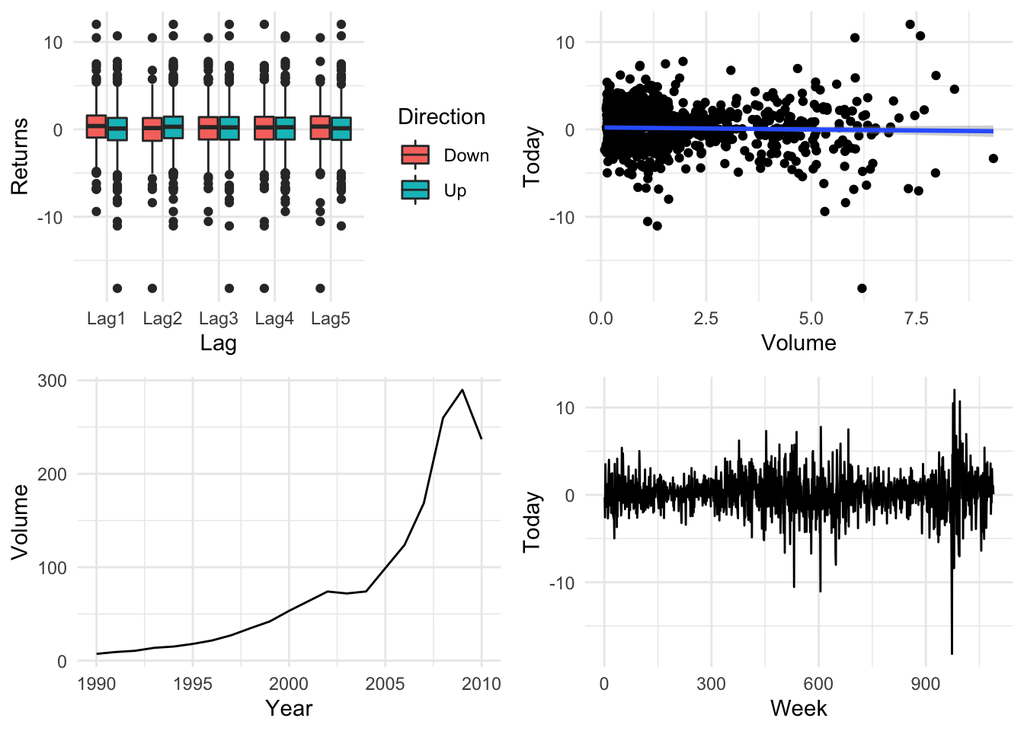

```r
lags <- Weekly %>%
  select(-Volume, -Today) %>%
  gather(key = Lag, value = Returns, -Direction, -Year) %>%
  ggplot() +
  geom_boxplot(aes(x = Lag, y = Returns, fill = Direction)) +
  theme_minimal()

vol_returns <- ggplot(data = Weekly, aes(x = Volume, y = Today)) +
  geom_point() +
  geom_smooth(method = "lm") +
  theme_minimal()

vol_year <- Weekly %>%
  group_by(Year) %>%
  summarise(Volume = sum(Volume)) %>%
  ggplot() +
  geom_line(aes(x = Year, y = Volume)) +
  theme_minimal()
returns <- mutate(Weekly, Week = 1:n()) %>%
  ggplot(aes(x = Week, y = Today)) +
  geom_line() +
  theme_minimal()

gridExtra::grid.arrange(lags, vol_returns, vol_year, returns, nrow = 2, ncol = 2)
```

**Use the full data set to perform a logistic regression with `Direction` as the response and the five lag variables plus `Volume` as predictors. Use the summary function to print the results. Do any of the predictors appear to be statistically significant? If so, which ones?**

```r
fit <- glm(Direction ~ Lag1 + Lag2 + Lag3 + Lag4 + Lag5 + Volume,
           family = "binomial",
           data = Weekly)

summary(fit)
```

```
##
## Call:
## glm(formula = Direction ~ Lag1 + Lag2 + Lag3 + Lag4 + Lag5 +
##     Volume, family = "binomial", data = Weekly)
##
## Deviance Residuals:
##     Min       1Q   Median       3Q      Max
## -1.6949  -1.2565   0.9913   1.0849   1.4579
##
## Coefficients:
##             Estimate Std. Error z value Pr(>|z|)
## (Intercept)  0.26686    0.08593   3.106   0.0019 **
## Lag1        -0.04127    0.02641  -1.563   0.1181
## Lag2         0.05844    0.02686   2.175   0.0296 *
## Lag3        -0.01606    0.02666  -0.602   0.5469
## Lag4        -0.02779    0.02646  -1.050   0.2937
## Lag5        -0.01447    0.02638  -0.549   0.5833
## Volume      -0.02274    0.03690  -0.616   0.5377
## ---
## Signif. codes:  0 '***' 0.001 '**' 0.01 '*' 0.05 '.' 0.1 ' ' 1
##
## (Dispersion parameter for binomial family taken to be 1)
##
##     Null deviance: 1496.2  on 1088  degrees of freedom
## Residual deviance: 1486.4  on 1082  degrees of freedom
## AIC: 1500.4
##
## Number of Fisher Scoring iterations: 4
```

Only `Lag2` appears to be significant at the 95% level. The positive coefficient suggests that positive returns 2 weeks ago are associated with positive returns today.

**Compute the confusion matrix and overall fraction of correct predictions. Explain what the confusion matrix is telling you about the types of mistakes made by logistic regression.**

```r
probs <- predict(fit, type = "response")
preds <- rep("Down", nrow(Weekly))
preds[probs > 0.5] <- "Up"
table(preds, Weekly$Direction)
```

```
##
## preds  Down  Up
##   Down   54  48
##   Up    430 557
```

```r
mean(preds == Weekly$Direction)
```

```
## [1] 0.5610652
```

The predictions appear to suggest that the logistic regression model predicts a high number of false positives - i.e. when the market goes down, logistic regression usually predicts up. The opposite problem is not the case here - the model rarely predicts the market going down where the actual result was up. The overall fraction of correct predictions suggests that the model is slightly better than a coin flip.

**Now fit the logistic regression model using a training data period from 1990 to 2008, with `Lag2` as the only predictor. Compute the confusion matrix and the overall fraction of correct predictions for the held out data (that is, the data from 2009 and 2010).**

```r
train <- subset(Weekly, Weekly$Year <= 2008)
fit2 <- glm(Direction ~ Lag2, data = train, family = "binomial")
summary(fit2)
```

```
##
## Call:
## glm(formula = Direction ~ Lag2, family = "binomial", data = train)
##
## Deviance Residuals:
##    Min      1Q  Median      3Q     Max
## -1.536  -1.264   1.021   1.091   1.368
##
## Coefficients:
##             Estimate Std. Error z value Pr(>|z|)
## (Intercept)  0.20326    0.06428   3.162  0.00157 **
## Lag2         0.05810    0.02870   2.024  0.04298 *
## ---
## Signif. codes:  0 '***' 0.001 '**' 0.01 '*' 0.05 '.' 0.1 ' ' 1
##
## (Dispersion parameter for binomial family taken to be 1)
##
##     Null deviance: 1354.7  on 984  degrees of freedom
## Residual deviance: 1350.5  on 983  degrees of freedom
## AIC: 1354.5
##
## Number of Fisher Scoring iterations: 4
```

```r
test <- subset(Weekly, Weekly$Year > 2008)
probs2 <- predict(fit2, test, type = "response")
preds2 <- rep("Down", nrow(test))
preds2[probs2 > 0.5] <- "Up"
table(preds2, test$Direction)
```

```
##
## preds2 Down Up
##   Down    9  5
##   Up     34 56
```

```r
mean(test$Direction == preds2)
```

```
## [1] 0.625
```

**Repeat (d) using LDA.**

```r
fit3 <- lda(Direction ~ Lag2, data = train)
fit3
```

```
## Call:
## lda(Direction ~ Lag2, data = train)
##
## Prior probabilities of groups:
##      Down        Up
## 0.4477157 0.5522843
##
## Group means:
##             Lag2
## Down -0.03568254
## Up    0.26036581
##
## Coefficients of linear discriminants:
##            LD1
## Lag2 0.4414162
```

```r
preds3 <- predict(fit3, test)
table(preds3$class, test$Direction)
```

```
##
##        Down Up
##   Down    9  5
##   Up     34 56
```

```r
mean(preds3$class == test$Direction)
```

```
## [1] 0.625
```

As expected LDA results are similar to logistic regression.

**Repeat (d) using QDA.**

```r
fit4 <- qda(Direction ~ Lag2, data = train)
fit4
```

```
## Call:
## qda(Direction ~ Lag2, data = train)
##
## Prior probabilities of groups:
##      Down        Up
## 0.4477157 0.5522843
##
## Group means:
##             Lag2
## Down -0.03568254
## Up    0.26036581
```

```r
preds4 <- predict(fit4, test)
table(preds4$class, test$Direction)
```

```
##
##        Down Up
##   Down    0  0
##   Up     43 61
```

```r
mean(preds4$class == test$Direction)
```

```
## [1] 0.5865385
```

QDA results are not good - it is outperformed by LDA and logistic regression and always picks ‘Up’

**Repeat (d) using KNN with $K$ = 1.**

```r
train_direction <- train[["Direction"]]
train_mat <- as.matrix(train[["Lag2"]])
test_mat <- as.matrix(test[["Lag2"]])
preds5 <- knn(train_mat, test_mat, train_direction, k = 1)
table(preds5, test[["Direction"]])
```

```
##
## preds5 Down Up
##   Down   21 29
##   Up     22 32
```

```r
mean(preds5 == test$Direction)
```

```
## [1] 0.5096154
```

KNN with $K$ = 1 perfoms worst of all, it’s essentially a coin flip.

**Which of these methods appears to provide the best results on this data?**

LDA and logistic regression performed best in predicting the test observations.

**Experiment with different combinations of predictors, including possible transformations and interactions, for each of the methods. Report the variables, method, and associated confu- sion matrix that appears to provide the best results on the held out data. Note that you should also experiment with values for $K$ in the KNN classifier.**

```r
glm.fit.interaction <- glm(Direction ~ Lag1*Lag2, data = train, family = "binomial")
prob.interaction <- predict(glm.fit.interaction, test, type = "response")
pred.interaction <- ifelse(prob.interaction > 0.5, "Up", "Down")
table(pred.interaction, test$Direction)
```

```
##
## pred.interaction Down Up
##             Down    7  8
##             Up     36 53
```

```r
mean(pred.interaction == test$Direction)
```

```
## [1] 0.5769231
```

Including an interaction term with logistic regression gives us a lower accuracy than the single predictor model.

Now try with an additional predictor, `Lag1`:

```r
glm.fit.lag1 <- glm(Direction ~ Lag1 + Lag2, data = train, family = "binomial")
prob.lag1 <- predict(glm.fit.lag1, test, type = "response")
pred.lag1 <- ifelse(prob.lag1 > 0.5, "Up", "Down")
table(pred.lag1, test$Direction)
```

```
##
## pred.lag1 Down Up
##      Down    7  8
##      Up     36 53
```

```r
mean(pred.lag1 == test$Direction)
```

```
## [1] 0.5769231
```

Again, including `Lag1` also worsens performance.

Now try transforming `Lag2`:

```r
glm.fit.sq <- glm(Direction ~ poly(Lag2, 2), data = train, family = "binomial")
prob.sq <- predict(glm.fit.sq, test, type = "response")
pred.sq <- ifelse(prob.sq > 0.5, "Up", "Down")
table(pred.sq, test$Direction)
```

```
##
## pred.sq Down Up
##    Down    8  4
##    Up     35 57
```

```r
mean(pred.sq == test$Direction)
```

```
## [1] 0.625
```

A square transformation appears to perform just as well as the single predictor model.

Now try these variations with LDA and QDA models:

```r
lda.inter <- lda(Direction ~ Lag1*Lag2, data = train)
pred.inter <- predict(lda.inter, test)
table(pred.inter$class, test$Direction)
```

```
##
##        Down Up
##   Down    7  8
##   Up     36 53
```

```r
mean(pred.inter$class == test$Direction)
```

```
## [1] 0.5769231
```

```r
lda.lag1 <- lda(Direction ~ Lag1 + Lag2, data = train)
pred.lag1 <- predict(lda.lag1, test)
table(pred.lag1$class, test$Direction)
```

```
##
##        Down Up
##   Down    7  8
##   Up     36 53
```

```r
mean(pred.lag1$class == test$Direction)
```

```
## [1] 0.5769231
```

```r
lda.sq <- lda(Direction ~ poly(Lag2, 2), data = train)
pred.sq <- predict(lda.sq, test)
table(pred.sq$class, test$Direction)
```

```
##
##        Down Up
##   Down    7  4
##   Up     36 57
```

```r
mean(pred.sq$class == test$Direction)
```

```
## [1] 0.6153846
```

The LDA models also don’t outperform the single variable models, but of these, that including the square transformation performs best.

Now try QDA:

```r
qda.inter <- qda(Direction ~ Lag1*Lag2, data = train)
pred.inter <- predict(qda.inter, test)
table(pred.inter$class, test$Direction)
```

```
##
##        Down Up
##   Down   23 36
##   Up     20 25
```

```r
mean(pred.inter$class == test$Direction)
```

```
## [1] 0.4615385
```

```r
qda.lag1 <- qda(Direction ~ Lag1 + Lag2, data = train)
pred.lag1 <- predict(qda.lag1, test)
table(pred.lag1$class, test$Direction)
```

```
##
##        Down Up
##   Down    7 10
##   Up     36 51
```

```r
mean(pred.lag1$class == test$Direction)
```

```
## [1] 0.5576923
```

```r
qda.sq <- qda(Direction ~ poly(Lag2, 2), data = train)
pred.sq <- predict(qda.sq, test)
table(pred.sq$class, test$Direction)
```

```
##
##        Down Up
##   Down    7  3
##   Up     36 58
```

```r
mean(pred.sq$class == test$Direction)
```

```
## [1] 0.625
```

Of the three models, the square transformation performs best, equalling the single predictor LDA and logistic regression test accuracy.

Now try a few different values for $k$ in a KNN classifier:

```r
set.seed(1)
k5pred <- knn(train_mat, test_mat, train_direction, k = 5)
table(k5pred, test$Direction)
```

```
##
## k5pred Down Up
##   Down   16 21
##   Up     27 40
```

```r
mean(k5pred == test$Direction)
```

```
## [1] 0.5384615
```

```r
k10pred <- knn(train_mat, test_mat, train_direction, k = 10)
table(k10pred, test$Direction)
```

```
##
## k10pred Down Up
##    Down   17 20
##    Up     26 41
```

```r
mean(k10pred == test$Direction)
```

```
## [1] 0.5576923
```

```r
k20pred <- knn(train_mat, test_mat, train_direction, k = 20)
table(k20pred, test$Direction)
```

```
##
## k20pred Down Up
##    Down   19 19
##    Up     24 42
```

```r
mean(k20pred == test$Direction)
```

```
## [1] 0.5865385
```

## Exercise 11

**In this problem, you will develop a model to predict whether a given car gets high or low gas mileage based on the `Auto` data set.**

**Create a binary variable, `mpg01`, that contains a 1 if `mpg` contains a value above its median, and a 0 if `mpg` contains a value below its median. You can compute the median using the `median()` function. Note you may find it helpful to use the `data.frame()` function to create a single data set containing both `mpg01` and the other Auto variables.**

```r
mpg01 <- ifelse(Auto$mpg > median(Auto$mpg), 1, 0)
auto_new <- data.frame(Auto, mpg01)
```

**Explore the data graphically in order to investigate the association between `mpg01` and the other features. Which of the other features seem most likely to be useful in predicting `mpg01`? Scatterplots and boxplots may be useful tools to answer this question. Describe your findings.**

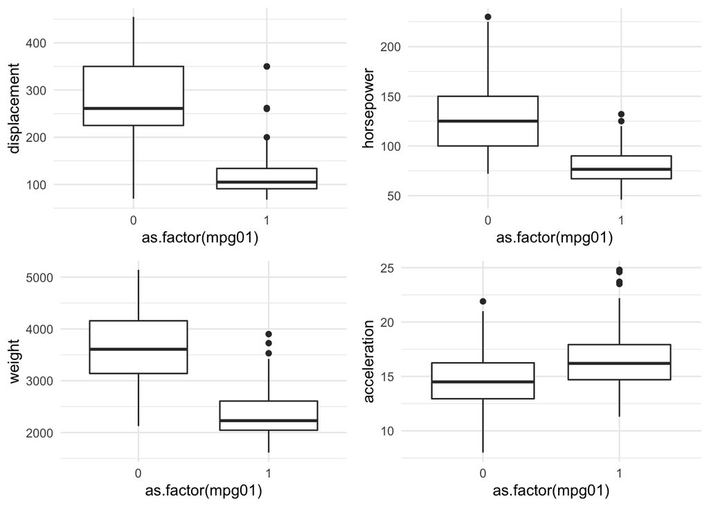

```r
disp <- ggplot(data = auto_new) +
  geom_boxplot(aes(x = as.factor(mpg01), y = displacement)) +
  theme_minimal()

horse <- ggplot(data = auto_new) +
  geom_boxplot(aes(x = as.factor(mpg01), y = horsepower)) +
  theme_minimal()

weight <- ggplot(data = auto_new) +
  geom_boxplot(aes(x = as.factor(mpg01), y = weight)) +
  theme_minimal()

acc <- ggplot(data = auto_new) +
  geom_boxplot(aes(x = as.factor(mpg01), y = acceleration)) +
  theme_minimal()

gridExtra::grid.arrange(disp, horse, weight, acc, ncol = 2, nrow = 2)
```

More fuel efficient cars are on average lighter, have lower displacement and horsepower, and better acceleration than less fuel efficient cars.

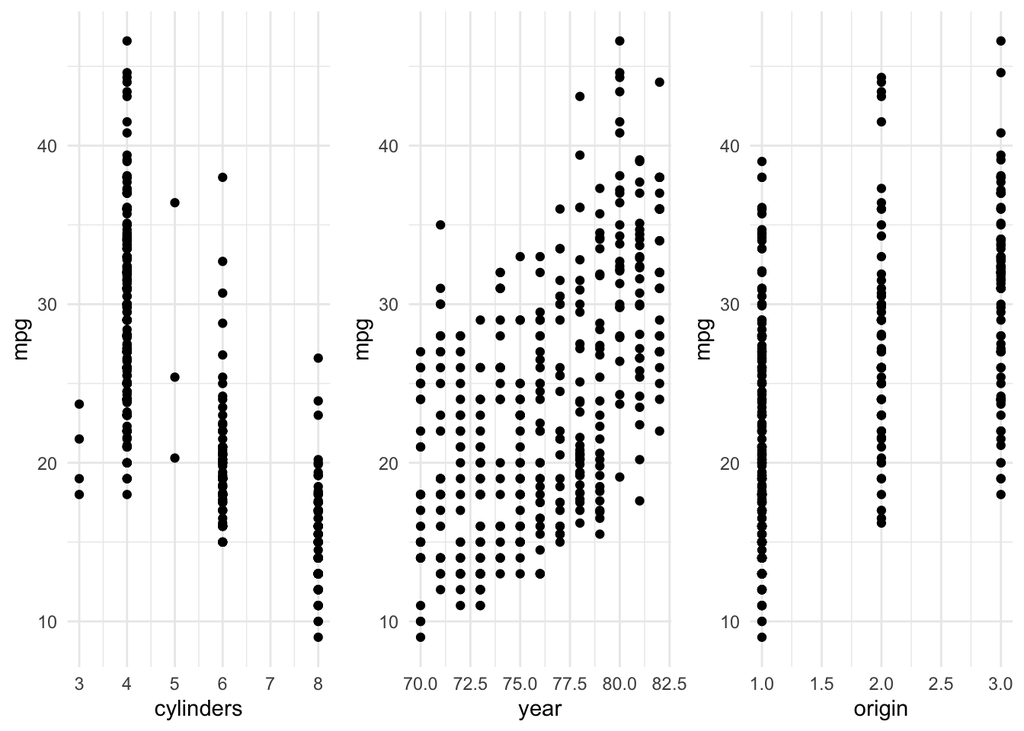

```r
cyl <- ggplot(data = auto_new) +
  geom_point(aes(x = cylinders, y = mpg)) +
  theme_minimal()

year <- ggplot(data = auto_new) +
  geom_point(aes(x = year, y = mpg)) +
  theme_minimal()

origin <- ggplot(data = auto_new) +
  geom_point(aes(x = origin, y = mpg)) +
  theme_minimal()

gridExtra::grid.arrange(cyl, year, origin, ncol = 3, nrow = 1)
```

`cylinders` is negatively associated with `mpg`, new cars are associated with higher `mpg`, and Japanese cars are most fuel efficient, followed by European, then American.

**Split the data into a training set and a test set.**

```r
set.seed(1)
auto_new$origin <- as.factor(auto_new$origin)
test_index <- sample(nrow(auto_new), 0.2 * nrow(auto_new))
test <- auto_new[test_index,]
train <- auto_new[-test_index,]
```

**Perform LDA on the training data in order to predict `mpg01` using the variables that seemed most associated with `mpg01` in (b). What is the test error of the model obtained?**

```r
lda.fit <- lda(mpg01 ~ cylinders + displacement + horsepower + weight + acceleration + year + origin, data = auto_new)
lda.fit
```

```
## Call:
## lda(mpg01 ~ cylinders + displacement + horsepower + weight +
##     acceleration + year + origin, data = auto_new)
##
## Prior probabilities of groups:
##   0   1
## 0.5 0.5
##
## Group means:
##   cylinders displacement horsepower   weight acceleration     year    origin2
## 0  6.765306     273.1582  130.11224 3620.403     14.58571 74.39796 0.07142857
## 1  4.178571     115.6658   78.82653 2334.765     16.49694 77.56122 0.27551020
##      origin3
## 0 0.04591837
## 1 0.35714286
##
## Coefficients of linear discriminants:
##                       LD1
## cylinders    -0.494144557
## displacement  0.002473972
## horsepower    0.008599215
## weight       -0.001263693
## acceleration  0.009269243
## year          0.130246233
## origin2       0.506485425
## origin3       0.392392121
```

```r
lda.pred <- predict(lda.fit, test)
mean(lda.pred$class != test$mpg01)
```

```
## [1] 0.06410256
```

LDA gives a test error rate of 6.4%.

**Perform QDA on the training data in order to predict `mpg01` using the variables that seemed most associated with `mpg01` in (b). What is the test error of the model obtained?**

```r
qda.fit <- qda(mpg01 ~ cylinders + displacement + horsepower + weight + acceleration + year + origin, data = auto_new)
qda.fit
```

```
## Call:
## qda(mpg01 ~ cylinders + displacement + horsepower + weight +
##     acceleration + year + origin, data = auto_new)
##
## Prior probabilities of groups:
##   0   1
## 0.5 0.5
##
## Group means:
##   cylinders displacement horsepower   weight acceleration     year    origin2
## 0  6.765306     273.1582  130.11224 3620.403     14.58571 74.39796 0.07142857
## 1  4.178571     115.6658   78.82653 2334.765     16.49694 77.56122 0.27551020
##      origin3
## 0 0.04591837
## 1 0.35714286
```

```r
qda.pred <- predict(qda.fit, test)
mean(qda.pred$class != test$mpg01)
```

```
## [1] 0.07692308
```

QDA gives a slightly higher test error of 7.7%.

**Perform logistic regression on the training data in order to predict `mpg01` using the variables that seemed most associated with `mpg01` in (b). What is the test error of the model obtained?**

```r
glm.fit <- glm(mpg01 ~ cylinders + displacement + horsepower + weight + acceleration + year + origin, data = auto_new, family = "binomial")
summary(glm.fit)
```

```
##
## Call:
## glm(formula = mpg01 ~ cylinders + displacement + horsepower +
##     weight + acceleration + year + origin, family = "binomial",
##     data = auto_new)
##
## Deviance Residuals:
##      Min        1Q    Median        3Q       Max
## -2.44937  -0.08809   0.00577   0.19315   3.03363
##
## Coefficients:
##                Estimate Std. Error z value Pr(>|z|)
## (Intercept)  -19.450793   5.956353  -3.266  0.00109 **
## cylinders     -0.264169   0.439645  -0.601  0.54793
## displacement   0.015568   0.013658   1.140  0.25434
## horsepower    -0.043081   0.024621  -1.750  0.08017 .
## weight        -0.005762   0.001376  -4.187 2.83e-05 ***
## acceleration   0.012939   0.142921   0.091  0.92786
## year           0.495635   0.086155   5.753 8.78e-09 ***
## origin2        1.971277   0.785573   2.509  0.01210 *
## origin3        1.102741   0.713768   1.545  0.12236
## ---
## Signif. codes:  0 '***' 0.001 '**' 0.01 '*' 0.05 '.' 0.1 ' ' 1
##
## (Dispersion parameter for binomial family taken to be 1)
##
##     Null deviance: 543.43  on 391  degrees of freedom
## Residual deviance: 152.30  on 383  degrees of freedom
## AIC: 170.3
##
## Number of Fisher Scoring iterations: 8
```

```r
glm.pred <- predict(glm.fit, test, type = "response")
preds <- rep(0, nrow(test))
preds[glm.pred > 0.5] <- 1
mean(preds != test$mpg01)
```

```
## [1] 0.07692308
```

Logistic regression also gives a test error rate of about 7.7%.

**Perform KNN on the training data, with several values of K, in order to predict `mpg01`. Use only the variables that seemed most associated with `mpg01` in (b). What test errors do you obtain? Which value of $K$ seems to perform the best on this data set?**

Trying KNN for different values of $K$:

```r
auto_new$us <- ifelse(auto_new$origin == 1, 1, 0)
auto_new$eu <- ifelse(auto_new$origin == 2, 1, 0)
train <- auto_new[-test_index,]
test <- auto_new[test_index,]

train_mat <- as.matrix(train[,-which(names(train) %in% c("name", "mpg01", "origin"))])
test_mat <- as.matrix(test[,-which(names(test) %in% c("name", "mpg01", "origin"))])

train_mpg01 <- train[, "mpg01"]

set.seed(1)
test_errs <- sapply(1:314, function(i) {
  knn.preds <- knn(train_mat, test_mat, train_mpg01, k = i)
  mean(knn.preds != test$mpg01)
})

which(test_errs == min(test_errs))
```

```
## [1] 3
```

$K$ = 3 gives the lowest test error rate of 0.1025641 but, judging from the plot below, some much higher values of $K$ still perform quite well. We may prefer to choose one of these values as a classifier with a higher $K$ is likely to have lower variance.

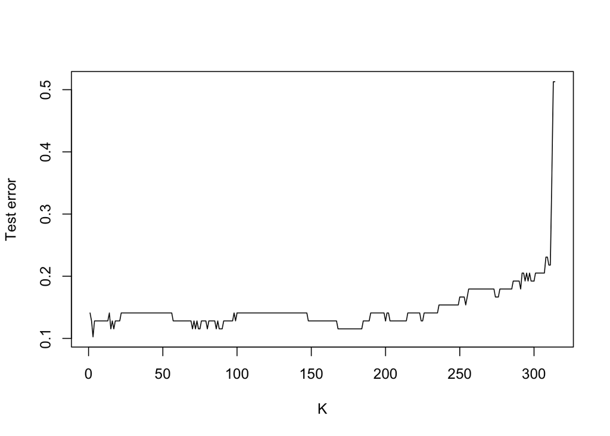

```r
plot(1:314, test_errs, type = "l", xlab = "K", ylab = "Test error")
```

## Exercise 12

**This problem involves writing functions.**

**Write a function, `Power()`, that prints out the result of raising 2 to the 3rd power. In other words, your function should compute 2<sup>3</sup> and print out the results.** *Hint: Recall that `x^a` raises `x` to the power `a`. Use the `print()` function to output the result.*

```r
Power <- function() {
  print(2^3)
}

Power()
```

```
## [1] 8
```

**Create a new function, `Power2()`, that allows you to pass any two numbers, `x` and `a`, and prints out the value of `x^a`. You can do this by beginning your function with the line**

```
Power2=function(x,a){
```

**You should be able to call your function by entering, for instance,**

```
Power2(3 ,8)
```

**on the command line. This should output the value of 3<sup>8</sup>, namely, 6,561.**

```r
Power2 <- function(x, a) {
  print(x^a)
}

Power2(3, 8)
```

```
## [1] 6561
```

**Using the `Power2()` function that you just wrote, compute 10<sup>3</sup>, 8<sup>17</sup>, and 131<sup>3</sup>.**

```r
Power2(10, 3)
```

```
## [1] 1000
```

```r
Power2(8, 17)
```

```
## [1] 2.2518e+15
```

```r
Power2(131, 3)
```

```
## [1] 2248091
```

**Now create a new function, `Power3()`, that actually returns the result `x^a` as an `R` object, rather than simply printing it to the screen. That is, if you store the value `x^a` in an object called `result` within your function, then you can simply `return()` this result, using the following line:**

```
return(result)
```

**The line above should be the last line in your function, before the `}` symbol.**

```r
Power3 <- function(x, a) {
  result <- x^a
  return(result)
}
```

**Now using the `Power3()` function, create a plot of $f(x)=x^2$. The x-axis should display a range of integers from 1 to 10, and the y-axis should display $x^2$. Label the axes appropriately, and use an appropriate title for the figure. Consider displaying either the x-axis, the y-axis, or both on the log-scale. You can do this by using `log = ''x''`, log=‘‘y’’, or `log=''xy''` as arguments to the `plot()` function.**

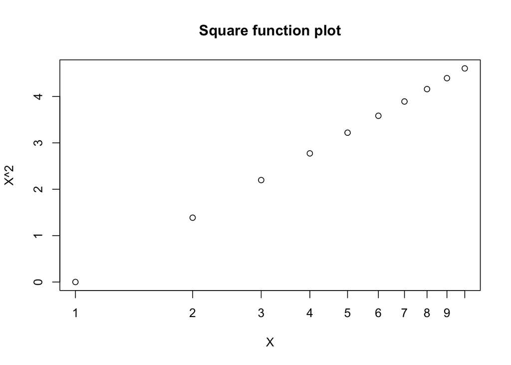

```r
plot(log(1:10), log(Power3(1:10, 2)), main = "Square function plot", xlab = "X", ylab = "X^2", xaxt= "n")
axis(side = 1, at = log(1:10), labels = 1:10)
```

**Create a function, `PlotPower()`, that allows you to create a plot of `x` against `x^a` for a fixed `a` and for a range of values of `x`. For instance, if you call**

```
PlotPower (1:10 ,3)
```

**then a plot should be created with an x-axis taking on values 1,2,…,10, and a y-axis taking on values 1<sup>3</sup>,2<sup>3</sup>,…,10<sup>3</sup>.**

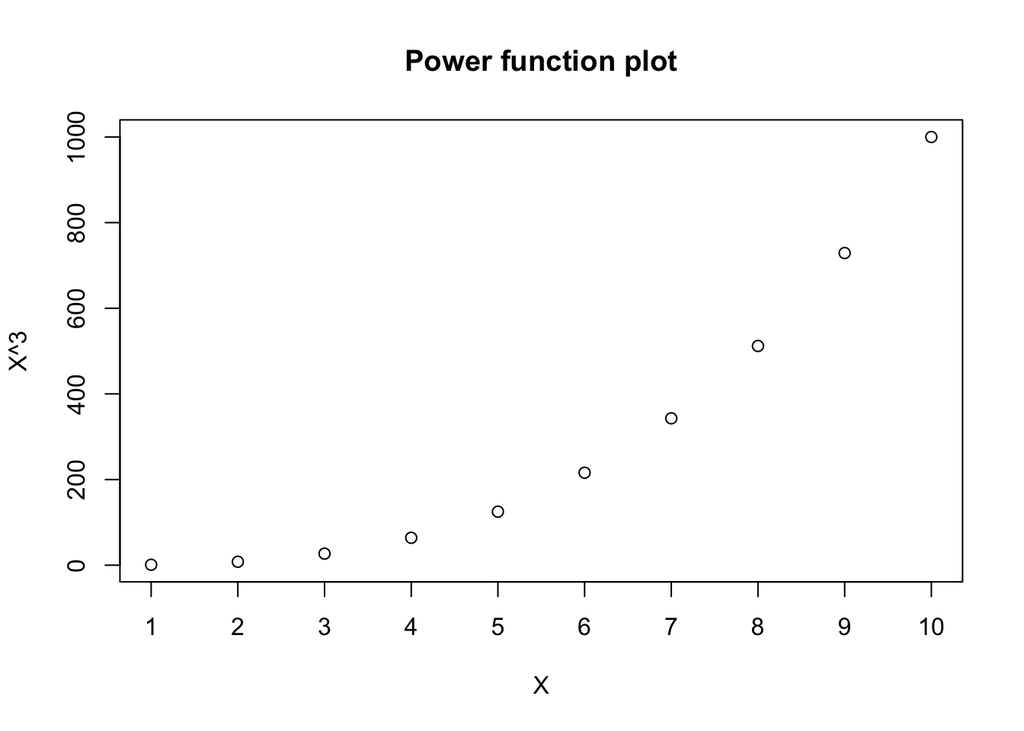

```r
PlotPower <- function(x, a) {
  plot(x, Power3(x, a), main = "Power function plot", xlab = "X", ylab = paste0("X^", a), xaxt= "n")
  axis(side = 1, at = x)
}
PlotPower(1:10, 3)
```

## Exercise 13

**Using the `Boston` data set, fit classification models in order to predict whether a given suburb has a crime rate above or below the median. Explore logistic regression, LDA, and KNN models using various sub-sets of the predictors. Describe your findings.**

```r
set.seed(1)
Boston$hiCrime <- factor(ifelse(Boston$crim > median(Boston$crim), "High", "Low"), levels = c("Low", "High"))
```

Summary statistics for `Boston`:

```r
summary(Boston)
```

```
##       crim                zn             indus            chas
##  Min.   : 0.00632   Min.   :  0.00   Min.   : 0.46   Min.   :0.00000
##  1st Qu.: 0.08205   1st Qu.:  0.00   1st Qu.: 5.19   1st Qu.:0.00000
##  Median : 0.25651   Median :  0.00   Median : 9.69   Median :0.00000
##  Mean   : 3.61352   Mean   : 11.36   Mean   :11.14   Mean   :0.06917
##  3rd Qu.: 3.67708   3rd Qu.: 12.50   3rd Qu.:18.10   3rd Qu.:0.00000
##  Max.   :88.97620   Max.   :100.00   Max.   :27.74   Max.   :1.00000
##       nox               rm             age              dis
##  Min.   :0.3850   Min.   :3.561   Min.   :  2.90   Min.   : 1.130
##  1st Qu.:0.4490   1st Qu.:5.886   1st Qu.: 45.02   1st Qu.: 2.100
##  Median :0.5380   Median :6.208   Median : 77.50   Median : 3.207
##  Mean   :0.5547   Mean   :6.285   Mean   : 68.57   Mean   : 3.795
##  3rd Qu.:0.6240   3rd Qu.:6.623   3rd Qu.: 94.08   3rd Qu.: 5.188
##  Max.   :0.8710   Max.   :8.780   Max.   :100.00   Max.   :12.127
##       rad              tax           ptratio          black
##  Min.   : 1.000   Min.   :187.0   Min.   :12.60   Min.   :  0.32
##  1st Qu.: 4.000   1st Qu.:279.0   1st Qu.:17.40   1st Qu.:375.38
##  Median : 5.000   Median :330.0   Median :19.05   Median :391.44
##  Mean   : 9.549   Mean   :408.2   Mean   :18.46   Mean   :356.67
##  3rd Qu.:24.000   3rd Qu.:666.0   3rd Qu.:20.20   3rd Qu.:396.23
##  Max.   :24.000   Max.   :711.0   Max.   :22.00   Max.   :396.90
##      lstat            medv       hiCrime
##  Min.   : 1.73   Min.   : 5.00   Low :253
##  1st Qu.: 6.95   1st Qu.:17.02   High:253
##  Median :11.36   Median :21.20
##  Mean   :12.65   Mean   :22.53
##  3rd Qu.:16.95   3rd Qu.:25.00
##  Max.   :37.97   Max.   :50.00
```

Split the data into a training and test set:

```r
train_idx <- sample(nrow(Boston), 0.7*nrow(Boston))
train <- Boston[train_idx,]
test <- Boston[-train_idx,]
```

First try a logistic regression with all predictors:

```r
glm.fit <- glm(hiCrime ~ . - crim, data = train, family = "binomial")
summary(glm.fit)
```

```
##
## Call:
## glm(formula = hiCrime ~ . - crim, family = "binomial", data = train)
##
## Deviance Residuals:
##     Min       1Q   Median       3Q      Max
## -2.1363  -0.1504  -0.0009   0.0018   3.5797
##
## Coefficients:
##               Estimate Std. Error z value Pr(>|z|)
## (Intercept) -42.731502   8.009551  -5.335 9.55e-08 ***
## zn           -0.105323   0.045585  -2.310 0.020862 *
## indus        -0.066308   0.057649  -1.150 0.250057
## chas          0.187896   0.810675   0.232 0.816711
## nox          56.344292  10.073420   5.593 2.23e-08 ***
## rm           -0.234402   0.900292  -0.260 0.794585
## age           0.022052   0.014304   1.542 0.123141
## dis           1.143918   0.303909   3.764 0.000167 ***
## rad           0.657976   0.184373   3.569 0.000359 ***
## tax          -0.006299   0.003239  -1.944 0.051849 .
## ptratio       0.292158   0.155755   1.876 0.060689 .
## black        -0.008703   0.005212  -1.670 0.094933 .
## lstat         0.112414   0.060168   1.868 0.061715 .
## medv          0.191745   0.087816   2.184 0.028999 *
## ---
## Signif. codes:  0 '***' 0.001 '**' 0.01 '*' 0.05 '.' 0.1 ' ' 1
##
## (Dispersion parameter for binomial family taken to be 1)
##
##     Null deviance: 490.65  on 353  degrees of freedom
## Residual deviance: 140.41  on 340  degrees of freedom
## AIC: 168.41
##
## Number of Fisher Scoring iterations: 9
```

```r
glm.prob <- predict(glm.fit, test, type = "response")
glm.pred <- ifelse(glm.prob > 0.5, "High", "Low")
table(glm.pred, test$hiCrime)
```

```
##
## glm.pred Low High
##     High  11   74
##     Low   62    5
```

```r
mean(glm.pred == test$hiCrime)
```

```
## [1] 0.8947368
```

```r
glm.fit <- glm(hiCrime ~ nox + rad + ptratio, data = train, family = "binomial")
summary(glm.fit)
```

```
##
## Call:
## glm(formula = hiCrime ~ nox + rad + ptratio, family = "binomial",
##     data = train)
##
## Deviance Residuals:
##      Min        1Q    Median        3Q       Max
## -2.02717  -0.32996  -0.05289   0.00675   2.57093
##
## Coefficients:
##              Estimate Std. Error z value Pr(>|z|)
## (Intercept) -19.43518    3.11187  -6.245 4.22e-10 ***
## nox          27.34885    3.73534   7.322 2.45e-13 ***
## rad           0.55638    0.12524   4.443 8.88e-06 ***
## ptratio       0.09724    0.09068   1.072    0.284
## ---
## Signif. codes:  0 '***' 0.001 '**' 0.01 '*' 0.05 '.' 0.1 ' ' 1
##
## (Dispersion parameter for binomial family taken to be 1)
##
##     Null deviance: 490.65  on 353  degrees of freedom
## Residual deviance: 185.53  on 350  degrees of freedom
## AIC: 193.53
##
## Number of Fisher Scoring iterations: 8
```

```r
glm.prob <- predict(glm.fit, test, type = "response")
glm.pred <- ifelse(glm.prob > 0.5, "High", "Low")
table(glm.pred, test$hiCrime)
```

```
##
## glm.pred Low High
##     High   6   65
##     Low   67   14
```

```r
mean(glm.pred == test$hiCrime)
```

```
## [1] 0.8684211
```

The more complex model performs better. Now try LDA for both sets of predictors:

```r
lda.fit <- lda(hiCrime ~ . - crim, data = train)
pred.lda <- predict(lda.fit, test)
table(pred.lda$class, test$hiCrime)
```

```
##
##        Low High
##   Low   70   20
##   High   3   59
```

```r
mean(pred.lda$class == test$hiCrime)
```

```
## [1] 0.8486842
```

```r
lda.fit <- lda(hiCrime ~ nox + rad + ptratio, data = train)
pred.lda <- predict(lda.fit, test)
table(pred.lda$class, test$hiCrime)
```

```
##
##        Low High
##   Low   70   19
##   High   3   60
```

```r
mean(pred.lda$class == test$hiCrime)
```

```
## [1] 0.8552632
```

The logistic regression models outperform LDA based on test accuracy.

Now try KNN for different values of $K$:

```r
train_mat <- as.matrix(train[, -15])
test_mat <- as.matrix(test[, -15])
train_res <- ifelse(train$hiCrime == "High", 1, 0)

k2pred <- knn(train_mat, test_mat, train_res, k = 2)
k5pred <- knn(train_mat, test_mat, train_res, k = 5)
k10pred <- knn(train_mat, test_mat, train_res, k = 10)
k20pred <- knn(train_mat, test_mat, train_res, k = 20)

table(k2pred, ifelse(test$hiCrime == "High", 1, 0))
```

```
##
## k2pred  0  1
##      0 65  3
##      1  8 76
```

```r
mean(k2pred == ifelse(test$hiCrime == "High", 1, 0))
```

```
## [1] 0.9276316
```

```r
table(k5pred, ifelse(test$hiCrime == "High", 1, 0))
```

```
##
## k5pred  0  1
##      0 62  6
##      1 11 73
```

```r
mean(k5pred == ifelse(test$hiCrime == "High", 1, 0))
```

```
## [1] 0.8881579
```

```r
table(k10pred, ifelse(test$hiCrime == "High", 1, 0))
```

```
##
## k10pred  0  1
##       0 59  8
##       1 14 71
```

```r
mean(k10pred == ifelse(test$hiCrime == "High", 1, 0))
```

```
## [1] 0.8552632
```

```r
table(k20pred, ifelse(test$hiCrime == "High", 1, 0))
```

```
##
## k20pred  0  1
##       0 59 11
##       1 14 68
```

```r
mean(k20pred == ifelse(test$hiCrime == "High", 1, 0))
```

```
## [1] 0.8355263
```

Of the values for $K$, 2 performs best, with a higher test accuracy than either logistic regression or LDA.